# Performance results

Jason Hu

April, 2019

## Plots

Here are some plots for the model performance. There are more explanations below. All plots are interactive. You can select regions to zoom in. You can select plots by double clicking its name on the right. Hover over the plot and you can see the nearest exact value.

Training cause of death.

```r
curve("tcod")
```

[interactive chart not shown]

Training time of event.

```r
curve("ttoe")
```

[interactive chart not shown]

Training receiver operating characteristic (sensitivity+specificity).

```r
curve("troc")
```

[interactive chart not shown]

Validation cause of death.

```r
curve("vcod")
```

[interactive chart not shown]

Validation time of event.

```r
curve("vtoe")
```

[interactive chart not shown]

Valiation receiver operating characteristic (sensitivity+specificity).

```r
curve("vroc")
```

[interactive chart not shown]

Valiation sensitivity.

```r
curve("vsen")
```

[interactive chart not shown]

Valiation specificity.

```r
curve("vspe")
```

[interactive chart not shown]

```r
curve(c("vroc","troc"), dnconly=TRUE)
```

[interactive chart not shown]

## Three evaluation metrics

ROC is my own formula of receiver operating characteristic, the sum of sensitivity (sen) and specificity (spe).

$$\large \text{myROC}= \text{sen} + \text{spe}$$

Cause-of-death is the average of binary cross entropy over all the ICD10 labels, including generated structured codes.

$$\large \text{cod}=-\frac{\sum_{i\in I}[y_i\log{\hat y_i} + (1-y_i)\log{1-\hat y_i}]}{|I|}$$
where $I$ is the set of ICD 10 codes.

Time-to-event is the average absolute difference in units of months between the actual death date and predicted death date.

$$\large \text{toe}=|t-\hat t|$$

The loss that the model directly learns from through back propagation is

$$\large l=\text{cod}+\beta \text{toe}$$

### Short aside: What is myROC?

Feel free to skip this section since my ROC is just sensitivity plus specificity. My ROC differs from the typical AUROC curve so I thought I might need to explain it.

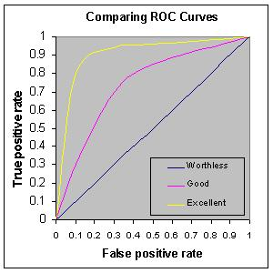

My ROC is not an integral of the area under, because only one point of ROC is sampled for each model, and a curve cannot be interpolated.

Another difference is that my ROC depends on sensitivity and specificity. Sensitivity is true positive rate, $\text{sen}=\text{TPR}$. Specificity is one minus false positive rate, $\text{spe}=1-\text{FPR}$. This means my ROC curve, if plotted, is flipped on x-axis compared to the typical ROC curve in figure above. Good classification in typical ROC curve should be on top left, aimed to maximize $\text{TPR} + (1 - \text{FPR})$. Good classification in my ROC curve should be on top right, aimed to maximize $\text{myROC}=\text{sen}+\text{spe}=\text{TPR}+(1-\text{FPR})$.

It’s just a matter of convention. My ROC is the optimization goal and is composed of clean and explainable components that needs to be improved simultaneously. Typical ROC aims to improve y-axis and reduce x-axis, which is confusing. AUC in other disciplines is usually oriented downwards, and there is no specific reason to flip the x-axis. Typical ROC optimize x-axis and y-axis in different directions.

## Experiment settings

16 runs in total

- 3 DNC runs
  - doubleDNC
  - priorDNC
  - onefourthDNC

    “Double” and “onefourth” denotes the parameter size. For example, doubleDNC has each DNC parameter size doubled. All models predict the log likelihood rather than the posterior probability, with known training set prior. DNC and priorDNC is the same thing.
- 7 ADNC runs
  - doubleADNC
  - APDNC
  - ouefourthADNC

    Similar to DNC runs with different parameter size. All models use priors: APDNC and ADNC is the same thing.
  - ADNCbi
  - ADNCDrop
  - ADNCMEM
  - ADNCNorm

    The ANDC is DNC with four extra modifications. Each model is a DNC with only one modification to isolate the effect. For example, ADNCbi is the DNC model with bidirectional LSTM.
- 3 LSTM runs
  - lstmG

    The standard LSTM. No prior.
  - priorlstm

    LSTM with prior.
  - lowbetapriorlstm

    Trained with low $\beta$ value to focus on cause of death predictions.
- 3 Tacotron runs
  - taco
  - priortaco
  - lowbetapriortaco

    Configurations similar to LSTM.

## Walkthrough and analysis

All models successfully retrieve information from the training set, demonstrated by loss going down from initial loss. But LSTM and Taoctron were only able to retrieve prior probability. For LSTM and Taoctron that do not have embedded prior, the initial loss starts with 0.69, a result of 50% randomly initialized prediction for each label. Within the first epoch, the loss drops to 0.09, the expected value for prediction with prior distribution, demonstrating the ability to retrieve information from training set. For LSTM and Tacotron with embedded prior, the initial loss starts with 0.09, a result of low log likelihood absolute value upon initialization. With or without prior, at training and validation, for both LSTM and Tacotron, the loss does not decrease further and receiver operating characteristic stays at 1, demonstarting inability to further recover information from the relationship between input and output. Though ROC stays at 1, the ratio between sensitivity and specificity changes for models with no embedded prior, starting from 50%-50% upon initialization to the average prior probability of 2.5%-97.5%, demonstarted by the initial outlier in the sensitivity and specificity plots. The best performance is a performance that the models can achieve without inputs, purely by the training set target distribution. This is also a performance that can be reached by betting each label with the training set prior distribution alone. I suspected that the failure of baseline performance is due to the relatively high $\beta$ value. I reduced $\beta$ from 1e-2 to 1e-8, and seen from the validation low beta plots, it does not address the problem.

ADNC is composed of four modifications on the original DNC model. It’s to my surprise that ADNC does not perform any better than DNC. I implemented all the modifications myself, according to the original paper. It could be due to my implementation error, but through the experiments, there does not seem to be an improvement on training or validation performance. All corresponding DNC and ADNC mdoels mirror each other’s performance. I initially thought this might be because one of the modifications is dragging the other three down, but the isolation experiments suggests that none of the modifications improve performance. In the original paper, there is visible improvement with each modification on their tasks. This might again be explained by the fact that our DNC architecture is not suitable for our study design. The improvement of ADNC over DNC as reported in ADNC paper is likely to further enhance the advantages of DNC on some particular domain tasks, but since DNC is not applicable to our task, no such advantages exist and can be enhanced. There can be other explanations available.

The models focus on the cause of death predictions, rather than time to event prediction. This is a matter of design. After all, there are far more signals within cause of death than a single number of time to event. There is no special architecture devoted to distinguishing the two goals, as the two targets are simply concatenated in the last layer, which one can argue to not be the optimal design, given the drastically different property between a binary label and a real target. However, we do see a visible decline in the error of time to event predictions in training time, meaning that this naive architecture is still able to recover a good amount of information from the training set. The variance on the validation time to event error is very high, and seems to display a U-shape, bottom at around epoch 6, at a value of 8 months on average prediction error. I should collect the training set standard deviation as a baseline, sorry about that. Notably, LSTM and Taoctron, albeit perfoming rather poorly on cause of death predictions, can predict the time to event well, achieving a similar U-shape as DNC, with smaller variance and somewhat poorer peak performance.

The reported ROC and loss here are evaluated on the structured death codes. The structured death codes contain more codes than the original. It’s likely that with the structured codes removed, the performance will be slightly worse. But if not-exact predictions are allowed, then this will be the final performance of all models.

The performance of DNC is better than LSTM and Tacotron, but the overall ROC is not very good compared to other statistical problems. This shows that our dataset and study design is very difficult. Given the difficulty of the study design, I think the ROC achievement is a meaningful result. I’m not sure whether the classifier will have clinical value. Although the sensitivity of the classifier is 14%, the base sensitivity is 2% only. It’s a signal augmentation of 7 times. It’s might not be a trivial model.

There does not seem to be any paper that I can compare my performance to. Doctor AI evaluates with top-k recall and R-squared. With no report on precision, the recall performance might be due to sparsity. DeepR only report accuracy, same problem. Deep patient aims at input reconstruction, which is essentially a different task. Only paper is “Predicting healthcare trajectories from medical records: A deep learning approach”, which reports AUC, but its AUC table is <0.5 on column 1 for table 2, which is theoretically impossible. Not sure the cause.

## Improvements?

Not many improvements on the models can be conducted at this stage.

I can spend some time to continue investigating the problem with LSTM and Tacotron, but it’s not likely that I will find anything. All training settings are the same, so it’s something with the models, but the models are not built by me, so it’s not likely to find problems with execution. Maybe LSTM and Tacotron are just not suitable.

There are a few hyperparameters that can still be tuned. The dropout is set to be 0.8, which can be changed. The overall parameter size seems to help ADNC to a small degree. Overfitting control is the key. There might be some techniques that I can apply to this problem.

All models have been saved. So if necessary, we can construct an ensemble model. But I have a feeling that with all the models performing relatively similarly stemming from the same DNC design, even if it reduces the variance slightly, it’s not likely to increase the expected ROC and loss by much, since I suspect that the model bias is the biggest problem here.

The structured codes might be improved. At the moment, a code like A123 is broken down to A, A1, A12, A123. It might be better to exclude short codes, because short codes, even for ICD10, can point to very different diseases and contribute to the majority of conditional positive labels.

I can collect more experiments about various experiment settings. For example, does ICD9 perform better than ICD10? Does structured codes help the training process? Will inclusion of underlying labels provide useful information? Why did curriculum learning not work? Etc.

I am happy to reorganize my code repository so that future researchers at Mayo can reuse it. I spent a lot of time working on the datset pipeline, certainly more time than building new models. For anyone who wants to test their own model on our REP dataset, they can save a lot of time just reusing my code. I can write an instruction on the functionalities of this repository and provide some minimal examples.

I’m open to suggestions. Overall, I am very happy with the work. Thank you Che for guiding me through this!